# Trabajo Práctico Final - Reseñas de vinos

Ankudowicz Santiago y Ferrero Kevin

## Introducción

Los datos corresponden a reseñas de vinos publicadas en la revista Wine Enthusiast.

Los datos originales fueron extraídos de [Kaggle](https://www.kaggle.com/zynicide/wine-reviews), que los obtuvo desde Wine Enthusiast la semana del 15 de junio de 2017. Luego fueron traducidos. En este informe estamos utilizando un archivo csv tal como fue provisto por el docente de la materia.

## Exploración de los datos

```r
# Código para cargar o leer los datos
vinos <- read.csv("datos/vinos.csv")
```

¿Qué variables tiene? Tiene 10 variables. Puedo averiguar esto utilizando str() o ls()

```r
# Uso la función str() para obtener una descripción sintética del data.frame "vinos"
str(vinos)
```

```
## 'data.frame':    129971 obs. of  10 variables:
##  $ pais         : chr  "Italia" "Portugal" "Estados Unidos" "Estados Unidos" ...
##  $ nombre       : chr  "Vulkà Bianco" "Avidagos" NA "Reserve Late Harvest" ...
##  $ puntos       : int  87 87 87 87 87 87 87 87 87 87 ...
##  $ precio       : int  NA 15 14 13 65 15 16 24 12 27 ...
##  $ provincia    : chr  "Sicily & Sardinia" "Douro" "Oregon" "Michigan" ...
##  $ region_1     : chr  "Etna" NA "Willamette Valley" "Lake Michigan Shore" ...
##  $ region_2     : chr  NA NA "Willamette Valley" NA ...
##  $ variedad     : chr  "Ensamblaje Blanco" "Portuguese Red" "Pinot Gris" "Riesling" ...
##  $ vina         : chr  "Nicosia" "Quinta dos Avidagos" "Rainstorm" "St. Julian" ...
##  $ titulo_resena: chr  "Nicosia 2013 Vulkà Bianco  (Etna)" "Quinta dos Avidagos 2011 Avidagos Red (Douro)" "Rainstorm 2013 Pinot Gris (Willamette Valley)" "St. Julian 2013 Reserve Late Harvest Riesling (Lake Michigan Shore)" ...
```

```r
# Uso ls() para listar los objetos (vectores) incluidos en "vinos"
ls(vinos)
```

```
##  [1] "nombre"        "pais"          "precio"        "provincia"
##  [5] "puntos"        "region_1"      "region_2"      "titulo_resena"
##  [9] "variedad"      "vina"
```

¿Cuántas observaciones hay? Hay 129.971 observaciones Este resultado también se obtiene de los resultados de str(). Alternativamente, se puede utilizar la función nrow()

```r
nrow(vinos)
```

```
## [1] 129971
```

¿Cuántas variables? Como ya dijimos, hay un total de 10 variables.

## Análisis de variables seleccionadas

Para lo anterior podemos utilizar la función summarise() y obtener algunos estádisticos para las variables numéricas: mínimo, máximo, promedio y desvìo estándar.

Cambiamos la estructura de datos para abreviar el código. Utilizamos la función pivot_longer para “alargar”

```r
vinos |>
  select(precio, puntos) |>
  pivot_longer(cols = 1:2, names_to = "variable", values_to = "valor") |>
  group_by(variable) |>
  summarise(promedio = mean(valor, na.rm = TRUE),
            sd = sd(valor, na.rm = TRUE),
            min = min(valor, na.rm = TRUE),
            max = max(valor, na.rm = TRUE))
```

```
## # A tibble: 2 × 5
##   variable promedio    sd   min   max
##   <chr>       <dbl> <dbl> <int> <int>
## 1 precio       35.4 41.0      4  3300
## 2 puntos       88.4  3.04    80   100
```

- ¿Hay alguna anomalía que sugiera que hay datos incorrectos? Valores imposibles (como valores negativos en una variable que sólo puede ser positiva) o poco creíbles.

No se observan valores atípicos para las variables precio y puntos. Específicamente para la variable precio, hay algunos valores muy por encima del resto, pero no parece tratarse de un error. De todas maneras, se podría recalcular el promedio excluyendo los valores extremos para evaluar su impacto sobre el precio promedio.

```r
vinos|>
  summarise(precio_promedio = mean(precio, trim = 0.001, na.rm = TRUE))
```

```
##   precio_promedio
## 1        34.66656
```

Como se observa el impacto de esta exclusión no es muy significativo.

Además, podemos graficar la cantidad de vinos reseñados para cada rango de precios utilizando un histograma.

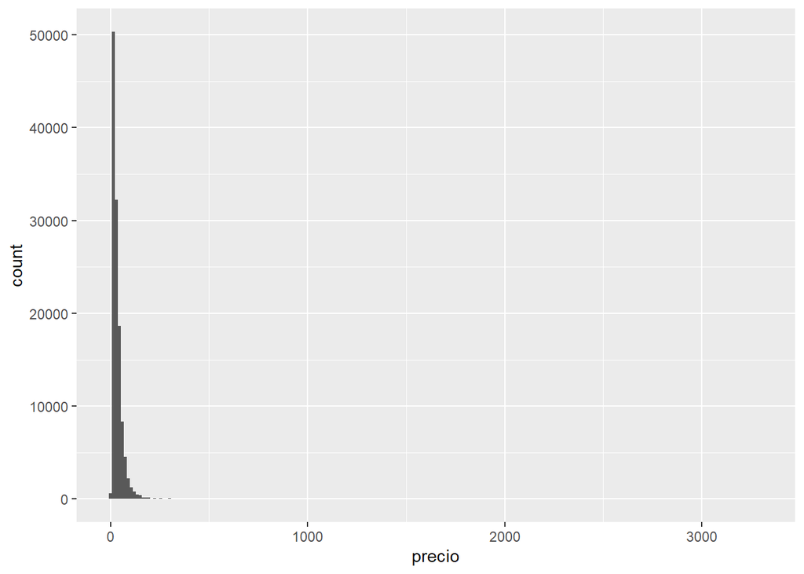

```r
vinos |>
  ggplot(aes(precio)) +
  geom_histogram(binwidth = 15)
```

Adicionalmente mostramos el mismo gráfico con un escala diferente para el eje x.

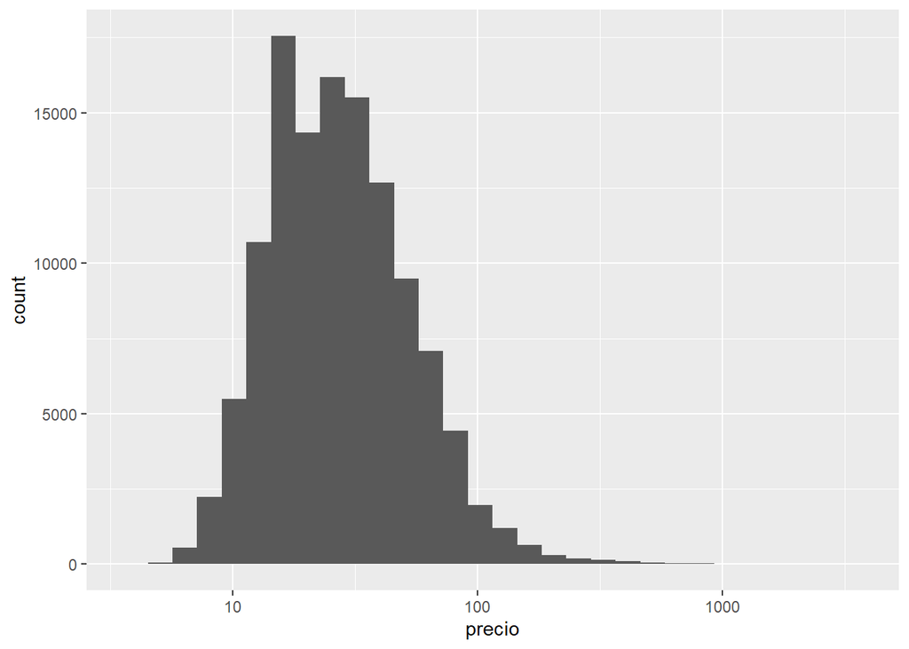

```r
vinos |>
  ggplot(aes(precio)) +
  geom_histogram() +
  scale_x_log10()
```

Esto nos confirma que son pocos los vinos con precios muy elevados.

- ¿Cuántas observaciones hay por cada grupo? ¿Cuántos valores faltantes? ¿Hay diferencias?

Para responder estas preguntas empezamos agrupando por país, detallando la cantidad de reseñas para cada uno y las presentamos en orden descendente

```r
vinos |>
  group_by(pais) |>
  summarise(cantidad_resenas= n()) |>
  arrange(desc(cantidad_resenas))
```

```
## # A tibble: 44 × 2
##    pais           cantidad_resenas
##    <chr>                     <int>
##  1 Estados Unidos            54504
##  2 Francia                   22093
##  3 Italia                    19540
##  4 España                     6645
##  5 Portugal                   5691
##  6 Chile                      4472
##  7 Argentina                  3800
##  8 Austria                    3345
##  9 Australia                  2329
## 10 Alemania                   2165
## # … with 34 more rows
```

Para saber cuantos valores faltantes hay por cada variable y en cada grupo, podemos hacer lo siguiente (almacenamos los resultados en un nuevo data.frame para utilizarlo luego con mayor facilidad)

```r
vinos_pais_nas <- vinos %>%
  group_by(pais) %>%
  summarise(cantidad_reseñas = n(),
            pais_nas = sum(is.na(pais)),
            nombre_nas = sum(is.na(nombre)),
            puntos_nas = sum(is.na(puntos)),
            precio_nas = sum(is.na(precio)),
            provincia_nas = sum(is.na(provincia)),
            region_1_nas = sum(is.na(region_1)),
            region_2_nas = sum(is.na(region_2)),
            variedad_nas = sum(is.na(variedad)),
            vina_nas = sum(is.na(vina)),
            titulo_resena_nas = sum(is.na(titulo_resena))) %>%
  arrange(desc(cantidad_reseñas))
```

Esto nos permite conocer la cantidad de valores faltantes de cada grupo para cada variable. Para evaluar si existen diferencias entre grupos resulta más conveniente ver la proporcion de valores faltantes en el total de reseñas, a continuación se presenta este procedimiento para la variable nombre a modo de ejemplo

```r
vinos_pais_nas <- vinos_pais_nas |>
  mutate(proporción_nombre_nas = nombre_nas/cantidad_reseñas)
```

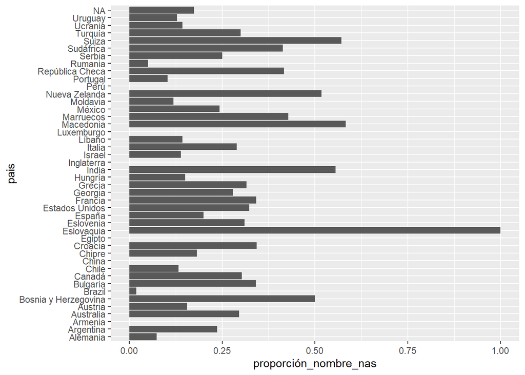

```r
vinos_pais_nas |>
  select(pais, proporción_nombre_nas, cantidad_reseñas) |>
  ggplot(aes(proporción_nombre_nas, pais)) +
  geom_col()
```

```r
#revisar las etiquetas que se superponen al mostrar el eje
```

La cantidad de nombres faltantes difiere entre paises. Este análisis podría replicarse para otras variables.

## Hipótesis

1- Los vinos de mayor precio reciben mayor puntaje.

Para obtener una primera aproximación a la validez de esta hipótesis, graficamos ambas variables

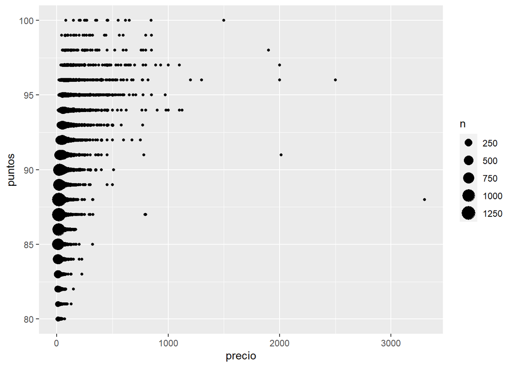

```r
vinos |>
  ggplot(aes( x = precio, y = puntos))+
  geom_count()
```

El gráfico no es muy concluyente. Calculamos el puntaje promedio que se obtiene para cada precio y graficamos los resultados

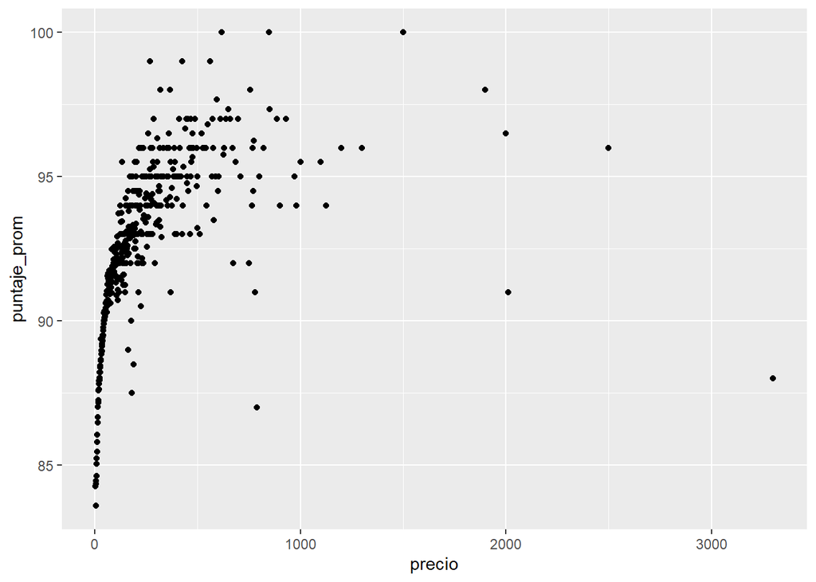

```r
vinos |>
  group_by(precio) |>
  summarise(puntaje_prom = mean(puntos)) |>
  ggplot(aes(x =  precio, y = puntaje_prom))+
  geom_point()
```

Utilizamos la función cut_width() para discretizar la variable continua “precio”.

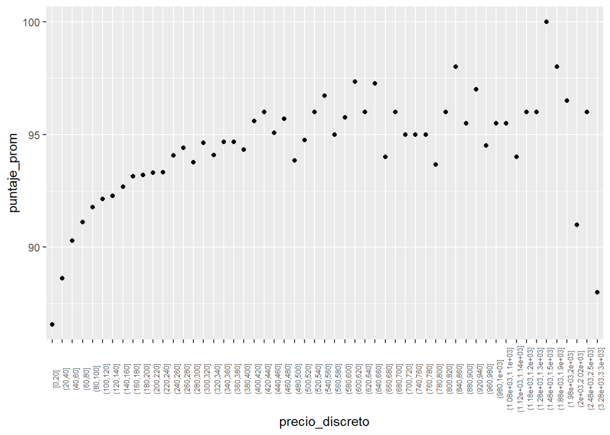

```r
vinos |>
  filter(is.na(precio) == FALSE) |>
  mutate(precio_discreto = cut_width(precio, width = 20, boundary = 0)) |>
  group_by(precio_discreto) |>
  summarise(puntaje_prom = mean(puntos)) |>
  ggplot(aes(x =  precio_discreto, y = puntaje_prom))+
  geom_point()+
  theme(axis.text.x = element_text(angle = 90, size = 6))
```

Para los vinos de menor precio se observa claramente que el puntaje promedio crece a la par que el precio se incrementa. Sin embargo, esa relación no se mantiene para todo el rango de precios, al menos no de forma inequívoca.

Recordando que la gran mayoría de los vinos se encuentran en un rango de precios bajo, podemos analizar la validez de la hipótesis separando las observaciones en dos conjuntos. Cómo parámetro para dividirlas utilizaremos el precio promedio más dos desvíos estándar de esta misma variable

```r
eje_x=vinos |>
  select(precio, puntos) |>
  pivot_longer(cols = 1:2, names_to = "variable", values_to = "valor") |>
  group_by(variable) |>
  summarise(promedio = mean(valor, na.rm = TRUE),
            sd = sd(valor, na.rm = TRUE),
            min = min(valor, na.rm = TRUE),
            max = max(valor, na.rm = TRUE)) |>
  filter(variable == "precio") |>
  mutate(eje_x = promedio+2*sd) |>
  select (eje_x)
```

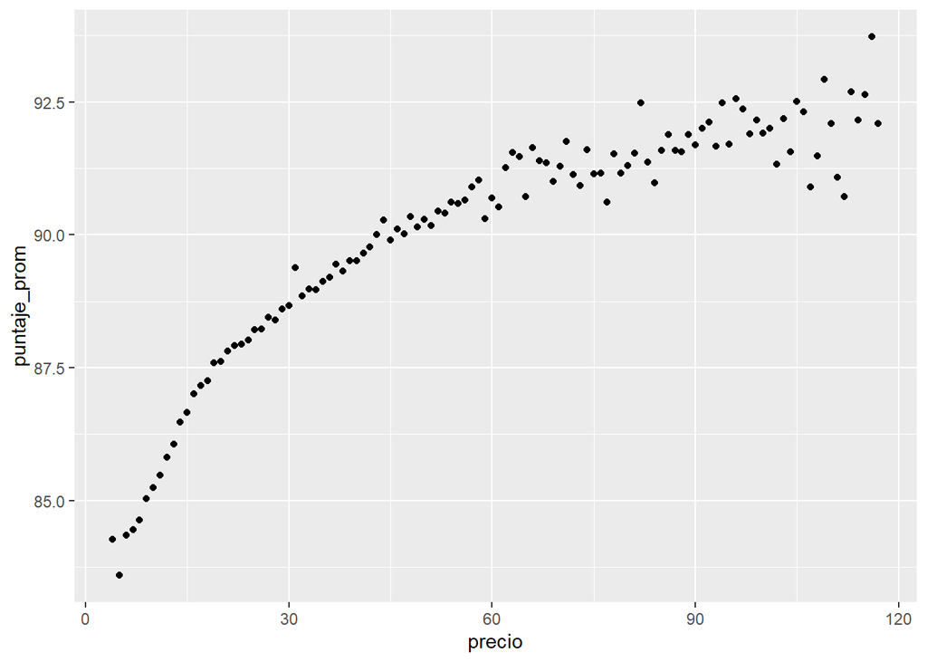

```r
vinos |>
  filter(precio <= as.numeric(eje_x)) |>
  group_by(precio) |>
  summarise(puntaje_prom = mean(puntos)) |>
  ggplot(aes(x = precio, y = puntaje_prom))+
  geom_point()
```

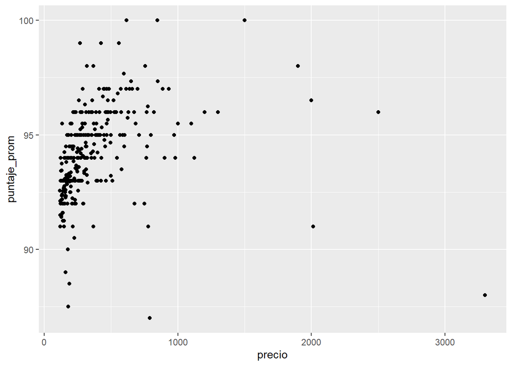

```r
vinos |>
  filter( precio >= as.numeric(eje_x)) |>
  group_by(precio) |>
  summarise(puntaje_prom = mean(puntos)) |>
  ggplot(aes(x = precio, y = puntaje_prom))+
  geom_point()
```

Estos últimos gráficos, permiten confirmar que nuestra hipótesis es compatible con vinos de precios bajos, pierde validez a medida que el precio crece y directamente no parece compatible con vinos de precios altos (por ejemplo mayores a 500 o 1000).

2- Para cada provincia las variedades reseñadas se concentran fuertemente en una variedad particular de vinos.

En primer lugar, calculamos la cantidad de reseñas que corresponde a cada provincia.

```r
resenas_provincia <- vinos |>
  group_by(provincia) |>
  summarise(cantidad_resenas_prov = n()) |>
  arrange(desc(cantidad_resenas_prov))
```

Luego generamos un indicador sencillo que permita apreciar cuánto representa la principal variedad reseñada de cada provincia en el total de reseñas de esa provicia.

```r
concentracion_provincia <- vinos |>
  group_by(provincia,variedad) |>
  summarise(cantidad_resenas_prov_var = n() ) |>
  arrange(desc(cantidad_resenas_prov_var)) |>
  left_join(resenas_provincia, by = "provincia") |>
  mutate(proporcion = cantidad_resenas_prov_var / cantidad_resenas_prov) |>
  select(provincia, variedad, proporcion, cantidad_resenas_prov_var, cantidad_resenas_prov) |>
  slice_max(proporcion, with_ties = FALSE) |>
  arrange(desc(cantidad_resenas_prov))
```

Filtramos las provincias que tienen una concentración mínima de 50%.

```r
concentracion_provincia |>
  filter(proporcion >= 0.5)
```

```
## # A tibble: 229 × 5
## # Groups:   provincia [229]
##    provincia  variedad              proporcion cantidad_resena… cantidad_resena…
##    <chr>      <chr>                      <dbl>            <int>            <int>
##  1 Bordeaux   Bordeaux-style Red B…      0.777             4617             5941
##  2 Oregon     Pinot Noir                 0.519             2786             5373
##  3 Burgundy   Chardonnay                 0.581             2312             3980
##  4 Piedmont   Nebbiolo                   0.714             2664             3729
##  5 Champagne  Champagne Ensamblaje       0.757             1221             1613
##  6 Provence   Rosé                       0.789             1062             1346
##  7 Douro      Portuguese Red             0.687              880             1281
##  8 Beaujolais Gamay                      0.945              987             1044
##  9 Mosel      Riesling                   0.973             1011             1039
## 10 Alentejano Portuguese Red             0.571              535              937
## # … with 219 more rows
```

Más de la mitad de las provincias (229 de 426) tienen una concrentración de al menos un 50% de sus reseñas explicadas por la principal variedad reseñada. Lo que confirma nuestra hipótesis.

3- Para las variedades de vinos más reseñadas, el precio difiere significativamente según se trate de vinos provenientes del hemisferio norte o del hemisferio sur.

Elaboramos un listado de los países de origen de los vinos reseñados y definimos manualmente el hemisferio al que pertenecen.

```r
pais_hemisferio <- vinos |>
  distinct(pais) |>
  arrange(pais) |>
  mutate(hemisferio = c("N","S","N","S","N","N","S","N","N","S","N","N","N","N","N","N","N","N","N","N","N","N","N","N","N","N","N","N","N","N","N","N","S","S","N","N","N","N","S","N","N","N","S",NA))
```

Luego generamos un nuevo set de datos que contenga el valor hemisferio que corresponde a cada país.

```r
vinos_hemisferio <- vinos |>
  left_join(pais_hemisferio, by = "pais")
```

A continuación, identificamos las principales variedades reseñadas. Podemos ver que las 10 principales tienen producción en ambos hemisferios.

```r
vinos_hemisferio |>
  filter(hemisferio == "N" | hemisferio == "S") |>
  group_by(variedad,hemisferio) |>
  summarise(cantidad_reseñas = n()) |>
  pivot_wider(names_from = hemisferio,values_from = cantidad_reseñas) |>
  mutate(total = N+S) |>
  arrange(desc(total)) |>
  head(10)
```

```
## # A tibble: 10 × 4
## # Groups:   variedad [10]
##    variedad                     N     S total
##    <chr>                    <int> <int> <int>
##  1 Pinot Noir               12123  1146 13269
##  2 Chardonnay               10253  1497 11750
##  3 Cabernet Sauvignon        7753  1717  9470
##  4 Ensamblaje Tinto          8105   830  8935
##  5 Bordeaux-style Red Blend  6642   273  6915
##  6 Riesling                  4946   242  5188
##  7 Sauvignon Blanc           3422  1541  4963
##  8 Syrah                     3698   444  4142
##  9 Rosé                      3416   147  3563
## 10 Merlot                    2696   405  3101
```

Definimos un nuevo objeto que contenga estas variedades.

```r
variedades_mas_resenadas <- vinos_hemisferio |>
  filter(hemisferio == "N" | hemisferio == "S") |>
  group_by(variedad,hemisferio) |>
  summarise(cantidad_reseñas = n()) |>
  pivot_wider(names_from = hemisferio,values_from = cantidad_reseñas) |>
  mutate(total = N+S) |>
  arrange(desc(total)) |>
  head(10) |>
  select(variedad)
```

Luego lo utilizamos para calcular el precio promedio de cada una según el hemisferio del país de origen y un ratio que relacione estos precios y nos permita evaluar la hipótesis.

```r
vinos_hemisferio |>
  filter(hemisferio =="N" | hemisferio =="S") |>
  semi_join(variedades_mas_resenadas, by = "variedad") |>
  group_by(variedad,hemisferio) |>
  summarise(precio_prom = mean(precio, na.rm = TRUE)) |>
  pivot_wider(names_from = hemisferio, values_from = precio_prom) |>
  mutate(ratio = N/S)
```

```
## # A tibble: 10 × 4
## # Groups:   variedad [10]
##    variedad                     N     S ratio
##    <chr>                    <dbl> <dbl> <dbl>
##  1 Bordeaux-style Red Blend  47.1  49.2 0.958
##  2 Cabernet Sauvignon        53.5  22.5 2.38
##  3 Chardonnay                36.7  20.4 1.80
##  4 Ensamblaje Tinto          35.9  35.8 1.00
##  5 Merlot                    31.7  15.2 2.08
##  6 Pinot Noir                49.3  28.4 1.74
##  7 Riesling                  32.6  20.9 1.55
##  8 Rosé                      18.7  14.5 1.29
##  9 Sauvignon Blanc           22.2  16.1 1.38
## 10 Syrah                     40.0  32.2 1.24
```

A simple vista, se observan diferencias significativas en el precio promedio de cada variedad según el hemisferio de dónde provengan. En general, el precio del hemisferio norte es más caro, en algunos casos más que duplicando el precio del hemisferio sur.

Verificamos si estas diferencias se deben a una mejor calidad de los vinos del norte. Para ello calculamos un indicador que refleje la valoración de cada vino en relación al precio pagado y comparamos para el mismo universo.

```r
vinos_hemisferio |>
  mutate(calidad = puntos/precio)|>
  filter(hemisferio =="N" | hemisferio =="S") |>
  semi_join(variedades_mas_resenadas, by = "variedad") |>
  group_by(variedad,hemisferio) |>
  summarise(calidad_prom = mean(calidad, na.rm = TRUE)) |>
  pivot_wider(names_from = hemisferio, values_from = calidad_prom) |>
  mutate(ratio = N/S)
```

```
## # A tibble: 10 × 4
## # Groups:   variedad [10]
##    variedad                     N     S ratio
##    <chr>                    <dbl> <dbl> <dbl>
##  1 Bordeaux-style Red Blend  3.37  2.61 1.29
##  2 Cabernet Sauvignon        2.70  5.48 0.492
##  3 Chardonnay                3.56  5.69 0.626
##  4 Ensamblaje Tinto          3.56  3.72 0.958
##  5 Merlot                    4.03  6.65 0.605
##  6 Pinot Noir                2.46  4.11 0.597
##  7 Riesling                  4.13  4.82 0.858
##  8 Rosé                      5.44  6.32 0.860
##  9 Sauvignon Blanc           4.67  6.04 0.773
## 10 Syrah                     2.84  4.41 0.645
```